# EPA-1316 Introduction to *Urban* Data Science

## Assignment 3: Prediction / Inference

**TU Delft**  
**Q1 2021**  
**Instructor:** Trivik Verma  
**TAs:** Auriane Técourt, Luka Janssens, Marya El Malki, Mobeen Nawaz, Stephan Olde, Ruth Nelson, Juliana Gonçalves  
**[Centre for Urban Science & Policy](https://cusp.tbm.tudelft.nl/)**

# `Instructions`

This assignment puts together what you learned in **Weeks 5-6**. Assignment 3 will build upon what you did in Assignment 2.

*Note:* Go through **labs and homeworks 05-06** before starting this assignment.

#### 1.1 Submission

Please submit the results by Brightspace under **Assignment 03**, using a single file as example,

```
firstname_secondname_thirdname_lastname_03.html
```

**If your file is not named in lowercase letters as mentioned above, your assignment will not be read by the script that works to compile 200 assignments and you will miss out on the grades. I don't want that, so be exceptionally careful that you name it properly. Don't worry if you spelled your name incorrectly. I want to avoid a situation where I have 200 assignments all called assignment_03.html**

Please **do not** submit any data or files other than the `html file`.

Don't worry about your submission *rendering without the images* **after** you submitted the file on brightspace. That is a brigthspace related issue of viewing your own submission but when I download all assignments as a batch file, I get all your images and code as you intended to submit. So make sure that your html shows everything you want us to see **before you submit**.

#### 1.2 How do you convert to HTML?

There are 2 ways,

1. from a running notebook, you can convert it into html by clicking on the file tab on the main menu of Jupyter Lab
   - File → Export Notebooks as... → Export Notebook to HTML
2. go to terminal or command line and type
   - `jupyter nbconvert --to html <notebook_name>.ipynb`

#### 1.3 Learning Objectives

This assignment is designed to support one learning objective. After completing the following exercises you will be able to:

- Explain the outcome of your models and relate them to your hypothesis.

# `Problem`

`Problem Statement`: While we all aspire to minimise crime, poverty, segregation or other inequitable and undesirable outcomes in society, it is necessary to first understand the severity of the issue and some of the most contributing factors or complex patterns that we may not completely understand without analysing the underlying data. It may come as a surprise, but a lot of these outcomes are ubiquitous in many parts of The Hague. For example, many neighbourhoods are quite poor, do not have access to public transport services or enough amenities and resources. A lot of these lacking infrastructure services result in complex socio-economic outcomes like gentrification, segregation, lack of jobs, excessive reliance on personal vehicle etc. Pinpointing the exact causes of such observations is impossible, as these are highly nuanced and complex issues. However, factors such as gross income, economic disparity, liveability and government infrastructure/support are often strong indicators. For example, it is widely believed that there’s an increase in crime in regions that have a large variance in citizens’ income levels. What is more, these neighbourhoods tend to cluster in space.

`What we expect`: Consider your hypothesis from **assignment 02**. In this assignment you are tasked with inspecting either 1). if there are natural clusters or dimensions in your data (an unsupervised learning - clustering problem), or 2). factors that may be correlated and/or contributing to a variable of your interest in the data (e.g., crime, poverty, liveability, etc). You should explore the same datasets from assignment 02 (they are mentioned again for clarity, below). Perform exploratory data analysis, iteratively refine your questions and chosen datasets, and produce plots to understand and communicate your findings. You may have done most of the exploration in assignment 02, so choosing the same hypothesis will save you time. You can use the contents of assignment-02. You are free to come up with a different hypothesis, but that would mean more time to go through data cleaning and EDA. I strongly advise to build upon assignment-02 and make certain improvements based on the feedback received.

Through this exercise, we expect you to think about your models in this assignment. What are the overall strengths and weaknesses of your models? Continue to improve your model to the best of your abilities. Lastly, comment on any additional ideas you have for a model that may be able to perform better, even if these ideas are not possible by any model that we have learned about in the course – for example, explain what type of information you wish your model could use, and how do you wish it could leverage that information. This doesn’t have to be explained in mathematical terms or theory, but the goal is to think about current limitations of models and how you wish to improve upon them.

`Example` If I look at crime, I'd start by looking at surface-level factors that may be correlated with crime, the conditions of a neighbourhood: presence of shops, schools, amenities. I'd start thinking about the following non-exhaustive list of questions:

- Are certain crimes more likely to occur where there is a dearth of amenities?
- Are there any characteristic clusters of high or low crime in space?
- Is there any correlation at all with busy areas and the locations of crimes? Or with rich areas and crime?
- How should I measure the presence of amentities or the richness of a neighbourhood?

`Assignment Goal`: Improving societal conditions for several communities is a complex, difficult, and slow process. You may not even have variables in your hypothesis that logically completely correlate with your variable of choice. But try! This is only practice. We want students to explore data and make statistical predictions in an area that is vastly affected by many confounding, real-world complex factors. The goal is for students to illustrate learned skills that align with our course goals. The primary goal of this project is to explain the outcomes of an event you observed and hypothesized in the datasets related to The Hague. Any piece of information from The Hague can be used to perform this analysis, but the suggested feature set should include the variables on the demographic information of The Hague (see below for datasets).

# `Data`

As part of the assignment files, I have provided you with the **first dataset**: the shapefiles of The Hague. After you unzip the data, we’ll work with the files of the form `neighborhoods.xxx`, in all the different geographic formats. Put the data in a convenient location on your computer or laptop, ideally in a folder called **data** which is next to this **jupyter notebook**. I recommend taking a look at the file with format `.json` in a text editor like *atom* for any system or notepad++ for windows. These will also make your life easy for everything else on your computer. Make sure you’ve set your working directory in the [correct manner](https://www.delftstack.com/howto/python/relative-path-in-python/).

It’s a big file and it may take a while to load onto your laptop and into Python (running on the jupyter labs environment).

As mentioned above in the problem introduction, you will use at least two datasets.

1. **First Dataset:** Download Shapefiles provided with the assignment
2. **Second Dataset:** Get a second dataset of your choice from The Hague city region using the links below (curate them as you like)

#### More Data Sources

You can find more data sources on Cities and Population, Climate indicators and Land-use in the following links.

Mikhail Sirenko has prepared the **first dataset** shapefiles with love and care so that you can connect it with either [Den Haag Cijfers](https://denhaag.incijfers.nl/jive) or [CBS](https://www.cbs.nl/nl-nl/reeksen/kerncijfers-wijken-en-buurten-2004-2020) datasets without having to clean any data. For the rest of the datasets, you may need to clean up.

*Note:* Data from CBS is only complete upto 2017. You will have to subset the data on municpality using the variable name `gm_naam = 's-Gravenhage` and then subset on neighbourhood resolution using variable name `recs = Buurt` to get the data that can match the shapefiles we have provided.

- https://denhaag.incijfers.nl/jive (available in English on the website)
- https://www.cbs.nl/nl-nl/reeksen/kerncijfers-wijken-en-buurten-2004-2020
- http://citypopulation.de/
- https://www.census.gov/programs-surveys/geography.html
- https://www.eea.europa.eu/data-and-maps
- http://download.geofabrik.de/

#### In case you get more data as shapefiles, and want to play with projections, a nice guide for it is [here](https://automating-gis-processes.github.io/CSC18/lessons/L2/projections.html)

# `Tasks`

For your convenience, the assignment has been divided into the following tasks,

1. Use Assignment 2 as a base for this assignment.
2. Build a regression or clustering model to analyse your hypothesis.
3. Use EDA, plot results, and make refinements to your models. (assignment 2 can be used here as a basis for your models - save time and remember the process is not linear!)
4. If you choose the regression path, perform error analyses, noting the best features, worst features, and any trends in supervised learning. If you choose the clustering path, explore which variables contribute the most to explaining the clusters using a principle component analysis. Report your results and provide in-depth analysis of the models using quick notes in markdown cells.
5. Discuss your results, model weaknesses and future ideas for improvements.

**A tip: you can use variations in the year of the data to use extra data in your observations. Does your model work for year 2016 and predict or cluster well for 2017?**

*Remember to always document your code! Justify everything you do (cleaning data, analysisng data, exploring data, defining hypothesis or measurements, etc.) using markdown cells as you go through the notebook.*

# `Start your analysis`

### 1. Make Hypothesis and clean data

```python
# your code here
# use many cells if you like to structure your code well
%matplotlib inline

import seaborn as sns
import pandas as pd
from pysal.lib import weights
import geopandas as gpd
import numpy as np
import matplotlib.pyplot as plt
from sklearn import cluster
from sklearn.linear_model import LinearRegression
import statsmodels.api as sm
from statsmodels.api import OLS
from sklearn import preprocessing
from sklearn.preprocessing import PolynomialFeatures
from sklearn.metrics import r2_score
from sklearn.model_selection import train_test_split
from sklearn.preprocessing import StandardScaler

from pandas.plotting import scatter_matrix

import seaborn as sns
from sklearn import linear_model
```

Changes in the real estate rental market can be related to many factors, such as the overall economic and social environment. Among them, the number of population represents the demand situation in the real estate market. Generally, a higher population represents a higher demand, and according to the supply and demand relationship, an increase in demand will drive an increase in rental prices, which will lead to an increase in market supply. Similarly, we assume that the number of people employed is related to the economic level of people, and that more people find jobs in The Hague may mean a higher demand for housing.

My hypothesis is the residential properties avaliable for rent will be more, with less population, less employments and less average home occupation.

There is evidence that the real estate vacancy is somewhat related to population, and in general, a large population and a relatively tight housing demand market, both for housing sales and rentals, will cause decrease of the amount of remaining houses available for rent; however, this is not absolute, and also depends on the housing price market and willingness to rent, as more demand will cause a corresponding rise in supply in a short period of time, thus reaching a new market equilibrium point.

The same applies to employment rates; in general, the greater the probability that people will find jobs and the higher the economic level, the higher the average occupancy rate of dwellings, the lower vacancies. However, this does not necessarily fit perfectly. A growing metropolis with more jobs will attract migrant workers, who usually do not purchase homes, and in cities with low vacancy rates, rental prices are bound to rise due to excessive demand, and thus some people cannot afford the high cost of renting a home.For the average housing occupancy, there is generally a negative correlation with the housing avaliable for rent.

We can download data we need and deal with the data to make it well-organized and clean.

```python
AHO = pd.read_csv("./data/Average Home Occupation  - Districts.csv", header = 2)
EMP = pd.read_csv("./data/Employement 2018 - Neighbourhoods.csv", header = 1)
POP = pd.read_csv("./data/Population 2018 - Neighbourhoods.csv", header = 1)
HAR = pd.read_csv("./data/Housing available for rent 2018 - Neighbourhoods.csv", header = 1)
```

```python
AHO.rename(columns = {'Unnamed: 0': 'Neighbourhood'},
           inplace = True)
AHO.index = AHO ['Neighbourhood']
AHO.head()
```

| Neighbourhood | Neighbourhood | 1996 | 1997 | 1998 | 1999 | 2000 | 2001 | 2002 | 2003 | 2004 | ... | 2012.1 | 2013.1 | 2014.1 | 2015.1 | 2016.1 | 2017.1 | 2018.1 | 2019.1 | 2020.1 | 2021.1 |
| --- | --- | --- | --- | --- | --- | --- | --- | --- | --- | --- | --- | --- | --- | --- | --- | --- | --- | --- | --- | --- | --- |
| 14 Bohemen, Meer en Bos | 14 Bohemen, Meer en Bos | NaN | NaN | NaN | NaN | NaN | NaN | NaN | NaN | NaN | ... | 1.52 | 1.53 | 1.53 | 1.55 | 1.54 | 1.56 | 1.58 | 1.54 | 1.57 | 1.56 |
| 15 Kijkduin en Ockenburgh | 15 Kijkduin en Ockenburgh | NaN | NaN | NaN | NaN | NaN | NaN | NaN | NaN | NaN | ... | 2.24 | 2.18 | 2.12 | 2.06 | 1.89 | 1.95 | 2.01 | 2.02 | 2.04 | 1.88 |
| 16 Kraayenstein en Vroondaal | 16 Kraayenstein en Vroondaal | NaN | NaN | NaN | NaN | NaN | NaN | NaN | NaN | NaN | ... | 1.98 | 2.00 | 2.01 | 1.98 | 2.02 | 2.09 | 2.14 | 2.20 | 2.26 | 2.32 |
| 17 Loosduinen | 17 Loosduinen | NaN | NaN | NaN | NaN | NaN | NaN | NaN | NaN | NaN | ... | 2.05 | 2.04 | 2.03 | 2.02 | 2.03 | 2.03 | 2.06 | 2.07 | 2.06 | 2.04 |
| 18 Waldeck | 18 Waldeck | NaN | NaN | NaN | NaN | NaN | NaN | NaN | NaN | NaN | ... | 1.72 | 1.72 | 1.73 | 1.72 | 1.74 | 1.76 | 1.75 | 1.77 | 1.75 | 1.75 |

5 rows × 53 columns

Now we can choose a certain year with less NA values(I choose based on AHO because for the general data like population and employment, the missing values of them are to a large extent less than the missing values of the special classification), we can see that for the year of 2018, we have 7 NA values.

We can rename the column name in the way we like and pick the columns we need so that we can merge them into a dataframe.

```python
print(np.sum([AHO.isnull()]))
print(np.sum([AHO['2015'].isnull()]))
print(np.sum([AHO['2016'].isnull()]))
print(np.sum([AHO['2017'].isnull()]))
print(np.sum([AHO['2018'].isnull()]))
print(np.sum([AHO['2019'].isnull()]))
```

```
1427
51
51
10
7
51
```

```python
EMP.rename(columns = {'Unnamed: 0': 'Neighbourhood'},
           inplace = True)
EMP.index = EMP ['Neighbourhood']
```

```python
col_n2 = ['average home occupation (BAG) [residents/residential property]','Number of employed persons [persons]']
EMP = pd.DataFrame(EMP,columns = col_n2)
```

```python
POP.rename(columns = {'Unnamed: 0': 'Neighbourhood'},
           inplace = True)
POP.index = POP ['Neighbourhood']
```

```python
col_n3 = ['Number of residents per 1-1 [persons]']
POP = pd.DataFrame(POP,columns = col_n3)
```

```python
HAR.rename(columns = {'Unnamed: 0': 'Neighbourhood'},
           inplace = True)
HAR.index = HAR ['Neighbourhood']
```

```python
col_n4 = ['Number of residential properties available for rent [number]']
HAR = pd.DataFrame(HAR,columns = col_n4)
```

```python
HAR.rename(columns = {'Number of residential properties available for rent [number]': 'Number of housing available for rent [number]'},
           inplace = True)
```

```python
df1 = pd.merge(EMP,POP,how = 'left',on = ['Neighbourhood'])
```

```python
df = pd.merge(df1,HAR,how = 'left',on = ['Neighbourhood'])
```

In the data set, there are some missing values, after viewing, these missing values themselves are randomly distributed, considering that for the more complete data rows may be missing one or two feature values, we first choose to fill with the average value of the column, which has the advantage of being able to retain some of the data and try not to change the feature distribution of the data. If all of them are deleted directly, then it will lead to larger missing sample data, and when the proportion of missing data is large, especially when the missing data is not randomly distributed, direct deletion may cause the data to deviate.

```python
df.fillna(df.mean(),inplace=True)
df.tail()
```

| Neighbourhood | average home occupation (BAG) [residents/residential property] | Number of employed persons [persons] | Number of residents per 1-1 [persons] | Number of housing available for rent [number] |
| --- | --- | --- | --- | --- |
| NaN | NaN | 2461.596491 | 4802.036036 | 12.123596 |
| NaN | NaN | 2461.596491 | 4802.036036 | 12.123596 |
| NaN | NaN | 2461.596491 | 4802.036036 | 12.123596 |
| NaN | NaN | 2461.596491 | 4802.036036 | 12.123596 |
| Export date | Saturday 25 September 2021 | 2461.596491 | 4802.036036 | 12.123596 |

After checking, there is still some data missing, this is because indicator:neighborhood itself has no value, such data has no research significance at all, we can choose to delete directly.

```python
df = df.dropna()
```

By looking at the information, we can find there is no NA values.

```python
df.info()
```

```
<class 'pandas.core.frame.DataFrame'>
Index: 122 entries, 01 Oud Scheveningen to Export date
Data columns (total 4 columns):
 #   Column                                                          Non-Null Count  Dtype
---  ------                                                          --------------  -----
 0   average home occupation (BAG) [residents/residential property]  122 non-null    object
 1   Number of employed persons [persons]                            122 non-null    float64
 2   Number of residents per 1-1 [persons]                           122 non-null    float64
 3   Number of housing available for rent [number]                   122 non-null    float64
dtypes: float64(3), object(1)
memory usage: 4.8+ KB
```

```python
df["average home occupation (BAG) [residents/residential property]"] = pd.to_numeric(df["average home occupation (BAG) [residents/residential property]"],errors='coerce')
```

```python
import osmnx as ox, geopandas as gpd
%matplotlib inline
ox.config(log_console=True, use_cache=True)
```

```python
Hag_link = "./data/neighborhoods.shp"
Hag = gpd.read_file(Hag_link)
type(Hag)
```

```
geopandas.geodataframe.GeoDataFrame
```

```python
Hag.crs
```

```
<Geographic 2D CRS: EPSG:4326>
Name: WGS 84
Axis Info [ellipsoidal]:
- Lat[north]: Geodetic latitude (degree)
- Lon[east]: Geodetic longitude (degree)
Area of Use:
- name: World.
- bounds: (-180.0, -90.0, 180.0, 90.0)
Datum: World Geodetic System 1984
- Ellipsoid: WGS 84
- Prime Meridian: Greenwich
```

```python
Hag.head()
```

|  | neighb_cbs | neigb_cijf | geometry |
| --- | --- | --- | --- |
| 0 | Oostduinen | 70 Oostduinen | POLYGON ((4.30290 52.12832, 4.30298 52.12827, ... |
| 1 | Belgisch Park | 71 Belgisch Park | POLYGON ((4.28056 52.11706, 4.28053 52.11706, ... |
| 2 | Westbroekpark | 73 Westbroekpark | POLYGON ((4.29171 52.10745, 4.29181 52.10739, ... |
| 3 | Duttendel | 74 Duttendel | POLYGON ((4.32252 52.10768, 4.32252 52.10766, ... |
| 4 | Nassaubuurt | 48 Nassaubuurt | POLYGON ((4.31943 52.09247, 4.31943 52.09247, ... |

We can merge the cleaned data and the shp file.

```python
Hag_2018 = Hag.join(df, on='neigb_cijf')
```

```python
Hag_2018 = Hag_2018.fillna((df.mean()))
Hag_2018.head()
```

|  | neighb_cbs | neigb_cijf | geometry | average home occupation (BAG) [residents/residential property] | Number of employed persons [persons] | Number of residents per 1-1 [persons] | Number of housing available for rent [number] |
| --- | --- | --- | --- | --- | --- | --- | --- |
| 0 | Oostduinen | 70 Oostduinen | POLYGON ((4.30290 52.12832, 4.30298 52.12827, ... | 2.192072 | 2495.20952 | 4802.036036 | 12.123596 |
| 1 | Belgisch Park | 71 Belgisch Park | POLYGON ((4.28056 52.11706, 4.28053 52.11706, ... | 1.990000 | 4062.00000 | 8202.000000 | 52.000000 |
| 2 | Westbroekpark | 73 Westbroekpark | POLYGON ((4.29171 52.10745, 4.29181 52.10739, ... | 1.730000 | 367.00000 | 881.000000 | 7.000000 |
| 3 | Duttendel | 74 Duttendel | POLYGON ((4.32252 52.10768, 4.32252 52.10766, ... | 1.750000 | 2664.00000 | 1081.000000 | 3.000000 |
| 4 | Nassaubuurt | 48 Nassaubuurt | POLYGON ((4.31943 52.09247, 4.31943 52.09247, ... | 2.180000 | 4934.00000 | 1633.000000 | 7.000000 |

We can check again if there is no NA values.

```python
Hag_2018.isnull().any()
```

```
neighb_cbs                                                        False
neigb_cijf                                                        False
geometry                                                          False
average home occupation (BAG) [residents/residential property]    False
Number of employed persons [persons]                              False
Number of residents per 1-1 [persons]                             False
Number of housing available for rent [number]                     False
dtype: bool
```

```python
Hag_2018.to_csv("./data/assignment02-Hag_2018-cleaned.csv")
```

### 2.Visualization between variables

```python
Hag = pd.read_csv("./data/assignment02-Hag_2018-cleaned.csv")
```

```python
HAR = np.array(Hag['Number of housing available for rent [number]'])
AHO = np.array(Hag['average home occupation (BAG) [residents/residential property]'])
EMP = np.array(Hag['Number of employed persons [persons]'])
POP = np.array(Hag['Number of residents per 1-1 [persons]'])
```

We can do some data visualization to show the approximate relationship between the dependent and independent variables:

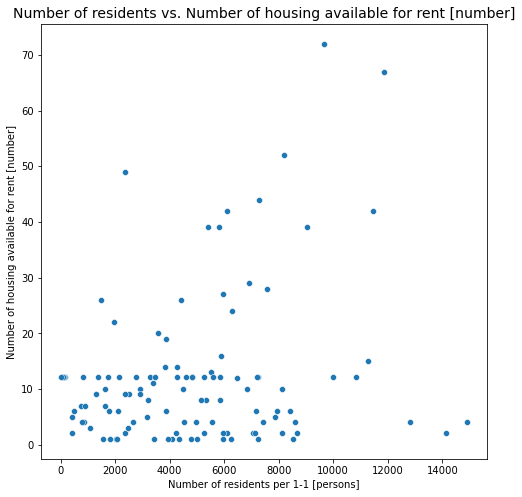

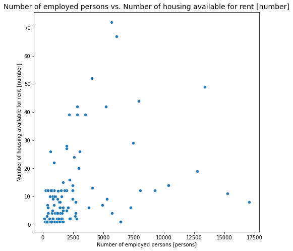

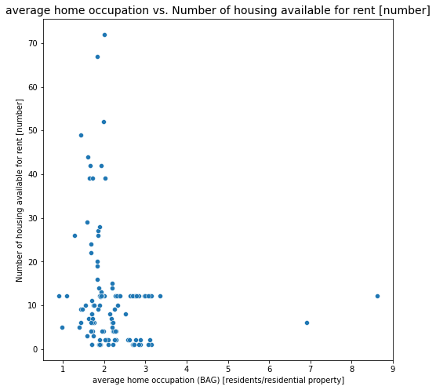

```python
f, ax = plt.subplots(1,1, figsize=(8, 8))
sns.scatterplot(x="Number of residents per 1-1 [persons]", y="Number of housing available for rent [number]", data=df, ax=ax);
ax.set_title('Number of residents vs. Number of housing available for rent [number]', fontsize=14)
plt.show();

f, ax = plt.subplots(1,1, figsize=(8, 8))
sns.scatterplot(x="Number of employed persons [persons]", y="Number of housing available for rent [number]",data=df, ax=ax);
ax.set_title('Number of employed persons vs. Number of housing available for rent [number]', fontsize=14)
plt.show();

f, ax = plt.subplots(1,1, figsize=(8, 8))
sns.scatterplot(x="average home occupation (BAG) [residents/residential property]", y="Number of housing available for rent [number]", data=df, ax=ax);
ax.set_title('average home occupation vs. Number of housing available for rent [number]', fontsize=14)
plt.show();
```

The scatter plot indicates the general trend of the dependent variable with the independent variable, according to which a suitable function can be selected to fit the data points. Two sets of data are used to form multiple coordinate points, and the distribution of the coordinate points is examined to determine whether there is some correlation between the two variables or to summarize the distribution pattern of the coordinate points. A scatter plot shows the series as a set of points. The values are indicated by the position of the points in the chart.

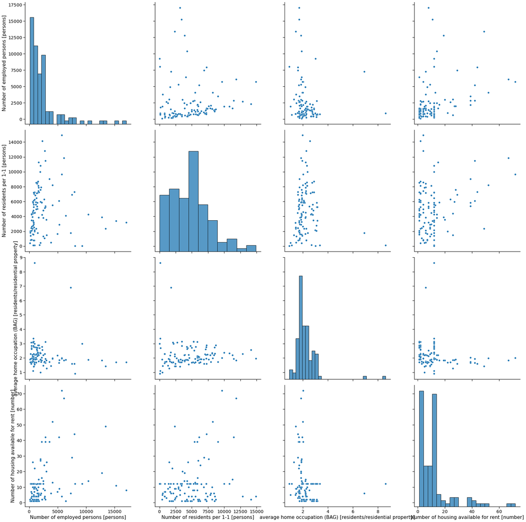

```python
numerical = ["Number of employed persons [persons]","Number of residents per 1-1 [persons]","average home occupation (BAG) [residents/residential property]","Number of housing available for rent [number]"]
sns.set_context("notebook", font_scale=1.3, rc={"lines.linewidth": 50})
df_to_plot = df.loc[:,numerical]
sns.pairplot(df_to_plot,height = 6);
plt.show()
```

```python
corr_matrix = df.corr()
corr_matrix['Number of housing available for rent [number]'].sort_values(ascending=False)
```

```
Number of housing available for rent [number]                     1.000000
Number of employed persons [persons]                              0.354641
Number of residents per 1-1 [persons]                             0.244865
average home occupation (BAG) [residents/residential property]   -0.155781
Name: Number of housing available for rent [number], dtype: float64
```

Based on this output, we can analyze the relationship between each independent variable and the dependent variables, we can see that two of the dependent variables are positively correlated with the Number of housing available for rent, while average home occupation (BAG) [residents/residential property] is negatively correlated with it.

So we can find that the results are partially in line with the hypothesis expectations. For the population, the possible reason is that with a larger population, the market curve for rental demand shifts to the right, causing prices to rise in the short term, which leads to an increase in supply (available rentals) and the market reaches a new equilibrium point. Because we only focus on the year of 2018(short-term), so this correlation can be explained by this way. However, if we look at the long-term perspective, the housing market will gradually reach stability, and housing will gradually reach saturation, at this time if the population keeps increasing, there is no extra housing available for rent, until all the houses are full, so there may be a long-term negative correlation, as we assumed. The same can be applied to employments, with more people get a job, the demand of renting a house will be higher, so that the supply will be higher in a short term.

On the other hand, it may be related to the local market prices, which may be too high for migrant workers to afford in a large city with more job opportunities. The presence of a train station in The Hague makes commuting very easy, so some migrant workers may live in the suburbs and the time cost is not as high compared to the cost of renting an apartment, so people don't necessarily rent a local house even if they get a job.

For the average home occupation (BAG), the relationship is in line with our expectations.

### 3. Simple Linear Regression

```python
AHO = AHO.reshape(-1,1)
HAR = HAR.reshape(-1,1)
```

We can determine the test size of the data = 0.3, then we focus on the variable of "average home occupation (BAG)".

And we can firstly assume from the plot that the relationship between average home occupation and housing avaliable for renting is simple linear regression :  
y = x1 * β 1 + α.

```python
trainHag, testHag = train_test_split(Hag, test_size=0.3, random_state=42)
```

```python
print("Shape of full dataset is: {0}".format(Hag.shape))
print("Shape of training dataset is: {0}".format(trainHag.shape))
print("Shape of test dataset is: {0}".format(testHag.shape))
```

```
Shape of full dataset is: (114, 8)
Shape of training dataset is: (79, 8)
Shape of test dataset is: (35, 8)
```

```python
trainHag.head()
```

|  | Unnamed: 0 | neighb_cbs | neigb_cijf | geometry | average home occupation (BAG) [residents/residential property] | Number of employed persons [persons] | Number of residents per 1-1 [persons] | Number of housing available for rent [number] |
| --- | --- | --- | --- | --- | --- | --- | --- | --- |
| 33 | 33 | Houtwijk | 86 Houtwijk | POLYGON ((4.259241171426233 52.06264402205376,... | 2.27 | 2710.0 | 12829.0 | 4.000000 |
| 62 | 62 | Zuidwal | 14 Zuidwal | POLYGON ((4.313511286155336 52.07827024080408,... | 1.59 | 7478.0 | 6900.0 | 29.000000 |
| 65 | 65 | Schildersbuurt-Oost | 17 Schildersbuurt-Oost | POLYGON ((4.315756202231278 52.06597179971767,... | 2.75 | 947.0 | 7241.0 | 12.123596 |
| 28 | 28 | Bohemen en Meer en Bos | 92 Bohemen/Meer en Bos | POLYGON ((4.24376263021411 52.06672286650215, ... | 1.56 | 958.0 | 4489.0 | 10.000000 |
| 42 | 42 | Heesterbuurt | 54 Heesterbuurt | POLYGON ((4.268146393379271 52.0756581752996, ... | 1.89 | 1036.0 | 6824.0 | 10.000000 |

```python
y_train = trainHag['Number of housing available for rent [number]']
```

```python
y_train.shape, type(y_train)
```

```
((79,), pandas.core.series.Series)
```

```python
x1_train = trainHag['average home occupation (BAG) [residents/residential property]']
```

```python
x1_train.shape, type(x1_train)
```

```
((79,), pandas.core.series.Series)
```

```python
x1_test = testHag['average home occupation (BAG) [residents/residential property]']
```

```python
y_test = testHag['Number of housing available for rent [number]']
```

```python
y_bar = np.mean(y_train)
x1_bar = np.mean(x1_train)

# build the two terms
numerator = np.sum( (x1_train - x1_bar)*(y_train - y_bar) )
denominator = np.sum((x1_train - x1_bar)**2)

print(numerator.shape, denominator.shape)
```

```
() ()
```

```python
#slope beta1
beta_1 = numerator/denominator

#intercept beta0
beta_0 = y_bar - beta_1*x1_bar

print("The best-fit line is {0:3.2f} + {1:3.2f} * x".format(beta_0, beta_1))
print(f'The best fit is {beta_0}')
```

```
The best-fit line is 15.88 + -1.75 * x
The best fit is 15.877351885811375
```

```python
# create the X matrix by appending a column of ones to x_train
X1 = sm.add_constant(x1_train)

# this is the same matrix as in our scratch problem!
print(X1)

# build the OLS model (ordinary least squares) from the training data
toyregr_sm = sm.OLS(y_train, X1)

# do the fit and save regression info (parameters, etc) in results_sm
results_sm = toyregr_sm.fit()

# pull the beta parameters out from results_sm
beta0_sm = results_sm.params[0]
beta1_sm = results_sm.params[1]

print(f'The regression coef from statsmodels are: beta_0 = {beta0_sm:8.6f} and beta_1 = {beta1_sm:8.6f}')
```

```
     const  average home occupation (BAG) [residents/residential property]
33     1.0                                           2.270000
62     1.0                                           1.590000
65     1.0                                           2.750000
28     1.0                                           1.560000
42     1.0                                           1.890000
..     ...                                                ...
106    1.0                                           2.840000
14     1.0                                           1.650000
92     1.0                                           6.900000
51     1.0                                           2.270000
102    1.0                                           2.192072

[79 rows x 2 columns]
The regression coef from statsmodels are: beta_0 = 15.877352 and beta_1 = -1.749111
```

```python
import warnings
warnings.filterwarnings('ignore')
print(results_sm.summary())
```

```
                                          OLS Regression Results
=========================================================================================================
Dep. Variable:     Number of housing available for rent [number]   R-squared:                       0.020
Model:                                                       OLS   Adj. R-squared:                  0.007
Method:                                            Least Squares   F-statistic:                     1.550
Date:                                           Fri, 15 Oct 2021   Prob (F-statistic):              0.217
Time:                                                   18:28:10   Log-Likelihood:                -313.38
No. Observations:                                             79   AIC:                             630.8
Df Residuals:                                                 77   BIC:                             635.5
Df Model:                                                      1
Covariance Type:                                       nonrobust
==================================================================================================================================
                                                                     coef    std err          t      P>|t|      [0.025      0.975]
----------------------------------------------------------------------------------------------------------------------------------
const                                                             15.8774      3.428      4.632      0.000       9.052      22.703
average home occupation (BAG) [residents/residential property]    -1.7491      1.405     -1.245      0.217      -4.547       1.048
==============================================================================
Omnibus:                       46.514   Durbin-Watson:                   1.989
Prob(Omnibus):                  0.000   Jarque-Bera (JB):              122.822
Skew:                           2.066   Prob(JB):                     2.14e-27
Kurtosis:                       7.500   Cond. No.                         6.55
==============================================================================

Notes:
[1] Standard Errors assume that the covariance matrix of the errors is correctly specified.
```

#### Recall the hypothesis, we assume:

H0 : There is no simple linear relationship between average home occupation and number of houses avaliable for rent.  
H1 : There is a simple linear relationship between average home occupation and number of houses avaliable for rent.

#### Based on the summary output,

- P value  
  The p value of the intercept term is 0.000, and at the significance level of 5%, we can reject the original hypothesis, i.e. which means that we can believe that the alpha estimate is significantly different from 0. The p value of the beta term is 0.217 and we cannot reject the null hypothesis at the same significance level of 5%.
- R ^2  
  We can see that R^2 is 0.02, while the adjusted R^2 is only 0.007. In general, R^ 2 is between 0 and 1, and the closer it is to 1, the better the model fits, so we can see that it is not valid to think that there is a simple linear relationship between the average house occupancy and the number of rentable houses.

### 4.Regression model

After checking one variable, we can combine all variables together to assume a hypothesis to see the complete model representation. Now recall my hypothesis, the null hypothesis should be :

H0 : There is no simple linear relationship between average home occupation, number of residents, number of employed persons and number of houses avaliable for rent.

H1: There are simple linear relationships between average home occupation, number of residents, number of employed persons and number of houses avaliable for rent.

#### The regression model: y = β1 *x1 + β2* x2 + β3* x3 + α

y - Number of housing available for rent  
x1 - Number of residents  
x2 - Number of employed persons  
x3 - average home occupation (BAG)  
β1 - coefficient of x1  
β2 - coefficient of x2  
β3 - coefficient of x3  
α - intercept

First we can check if the variables have the multicollinearity because if there is multicollinearity between the variables, then the model will lose its meaning.

```python
Hag_corr = Hag[["Number of employed persons [persons]","Number of residents per 1-1 [persons]","average home occupation (BAG) [residents/residential property]",'Number of housing available for rent [number]']]
Hag_corr.head()
```

|  | Number of employed persons [persons] | Number of residents per 1-1 [persons] | average home occupation (BAG) [residents/residential property] | Number of housing available for rent [number] |
| --- | --- | --- | --- | --- |
| 0 | 2495.20952 | 4802.036036 | 2.192072 | 12.123596 |
| 1 | 4062.00000 | 8202.000000 | 1.990000 | 52.000000 |
| 2 | 367.00000 | 881.000000 | 1.730000 | 7.000000 |
| 3 | 2664.00000 | 1081.000000 | 1.750000 | 3.000000 |
| 4 | 4934.00000 | 1633.000000 | 2.180000 | 7.000000 |

```python
print(Hag_corr.corr())
```

```
                                                    Number of employed persons [persons]  \
Number of employed persons [persons]                                            1.000000
Number of residents per 1-1 [persons]                                           0.029931
average home occupation (BAG) [residents/reside...                             -0.099533
Number of housing available for rent [number]                                   0.354643

                                                    Number of residents per 1-1 [persons]  \
Number of employed persons [persons]                                             0.029931
Number of residents per 1-1 [persons]                                            1.000000
average home occupation (BAG) [residents/reside...                              -0.041810
Number of housing available for rent [number]                                    0.244865

                                                    average home occupation (BAG) [residents/residential property]  \
Number of employed persons [persons]                                                        -0.099533
Number of residents per 1-1 [persons]                                                       -0.041810
average home occupation (BAG) [residents/reside...                                           1.000000
Number of housing available for rent [number]                                               -0.155781

                                                    Number of housing available for rent [number]
Number of employed persons [persons]                                                     0.354643
Number of residents per 1-1 [persons]                                                    0.244865
average home occupation (BAG) [residents/reside...                                      -0.155781
Number of housing available for rent [number]                                            1.000000
```

We can use VIF to double check as well:

```python
from statsmodels.stats.outliers_influence import variance_inflation_factor
```

```python
vif = [variance_inflation_factor(Hag_corr.values, Hag_corr.columns.get_loc(i)) for i in Hag_corr.columns]
vif
```

```
[1.8139538193676317, 2.876312350173738, 2.5606393832149066, 2.17890367833262]
```

By correlation check and VIF check, we can see all the correlation coefficient(R)<0.8, and for the variance inflation factor(VIF), they all < 5, which means all the variables didn't have the multicollinearity.

```python
X = Hag[["Number of residents per 1-1 [persons]","Number of employed persons [persons]","average home occupation (BAG) [residents/residential property]"]]
```

```python
y = Hag['Number of housing available for rent [number]']
y_train = y
```

```python
from sklearn.model_selection import train_test_split
X_train,X_test,y_train,y_test=train_test_split(X,y,test_size = 0.2,random_state=42)
```

```python
X_train.shape
```

```
(91, 3)
```

```python
y_train.shape
```

```
(91,)
```

```python
LR = LinearRegression()
```

```python
LR.fit(X_train,y_train)
```

```
LinearRegression()
```

```python
import statsmodels.api as sm
```

```python
X = sm.add_constant(X)
```

```python
est = sm.OLS(y,X)
```

```python
est = est.fit()
```

```python
est.params
```

```
const                                                             7.527203
Number of residents per 1-1 [persons]                             0.000961
Number of employed persons [persons]                              0.001459
average home occupation (BAG) [residents/residential property]   -1.671884
dtype: float64
```

```python
est.summary()
```

OLS Regression Results

| Dep. Variable: | Number of housing available for rent [number] | R-squared: | 0.193 |
| --- | --- | --- | --- |
| Model: | OLS | Adj. R-squared: | 0.171 |
| Method: | Least Squares | F-statistic: | 8.783 |
| Date: | Fri, 15 Oct 2021 | Prob (F-statistic): | 2.85e-05 |
| Time: | 18:28:10 | Log-Likelihood: | -445.04 |
| No. Observations: | 114 | AIC: | 898.1 |
| Df Residuals: | 110 | BIC: | 909.0 |
| Df Model: | 3 |  |  |
| Covariance Type: | nonrobust |  |  |

|  | coef | std err | t | P>\|t\| | [0.025 | 0.975] |
| --- | --- | --- | --- | --- | --- | --- |
| const | 7.5272 | 3.714 | 2.027 | 0.045 | 0.167 | 14.888 |
| Number of residents per 1-1 [persons] | 0.0010 | 0.000 | 2.683 | 0.008 | 0.000 | 0.002 |
| Number of employed persons [persons] | 0.0015 | 0.000 | 3.909 | 0.000 | 0.001 | 0.002 |
| average home occupation (BAG) [residents/residential property] | -1.6719 | 1.278 | -1.308 | 0.194 | -4.205 | 0.861 |

| Omnibus: | 39.966 | Durbin-Watson: | 1.675 |
| --- | --- | --- | --- |
| Prob(Omnibus): | 0.000 | Jarque-Bera (JB): | 85.328 |
| Skew: | 1.420 | Prob(JB): | 2.96e-19 |
| Kurtosis: | 6.146 | Cond. No. | 2.12e+04 |

Notes:  
[1] Standard Errors assume that the covariance matrix of the errors is correctly specified.  
[2] The condition number is large, 2.12e+04. This might indicate that there are  
strong multicollinearity or other numerical problems.

```python
y_pred = LR.predict(X_test)
y_pred
```

```
array([ 5.31476331, 12.19499633, 12.91196929, 10.95203864, 18.15988427,
       14.59217539,  9.36113324,  8.06038366, 10.24386627,  5.76353217,
        5.18689061, 12.26830426, 11.8254052 , 13.40233432, 22.40527618,
       11.95094909, 28.28459217, 10.41453302,  7.95351141, 30.46073101,
        6.85727761, 14.21627857,  7.84297144])
```

```python
from sklearn.metrics import mean_absolute_error
```

```python
print(f'Root Mean Squared Error :{np.sqrt(mean_absolute_error(np.log(y_test),np.log(y_pred)))}')
```

```
Root Mean Squared Error :0.9589435468393648
```

```python
from sklearn.model_selection import KFold
```

```python
kf = KFold(n_splits = 10)
rmse_scores = []

for train_indices, test_indices in kf.split(X,y):
    X_train, X_test = X.iloc[train_indices], X.iloc[train_indices]
    y_train, y_test = y.iloc[train_indices], y.iloc[train_indices]
    LR = LinearRegression(normalize = True)
    LR.fit(X_train,y_train)
    y_pred = LR.predict(X_test)
    rmse = np.sqrt(mean_absolute_error(np.log(y_test),np.log(abs(y_pred))))
    rmse_scores.append(rmse)

print("rmse scores:",rmse_scores)
```

```
rmse scores: [0.9691891406802466, 0.930013801313946, 0.9548513686443392, 0.9435283758117368, 0.9534771057833519, 0.9287515434382925, 0.9462262179262148, 0.926594289568535, 0.9729180166071343, 0.9346888747228305]
```

```python
print(f'average rmse scores :{np.mean(rmse_scores)}')
```

```
average rmse scores :0.9460238734496628
```

By doing 10-fold cross-validation, we can see that the Root Mean Squared Error slightly decreases from 0.9589 to 0.9460 compared to OLS model, which means the model has a better performance, but not very significant. The possible reason can be that our sample data is too small, in general, for the regression model with large data, the Kfold method will make the model performance better than orginal OLS model.

### 5.Increase the number of independent variables

Since the P values of the two variables are more significant, but the R^ 2 of the overall model is small（0.193）, which indicates a poor model fit, we can first speculate that because there are too few independent variables or variables that are truly related to the number of rentable houses in the dependent variable are not included in the model and therefore cannot explain the dependent variable, we can first include new independent variables to extend our hypothesis：

In addition to the variables already analyzed, we consider the addition of four new variables.

5). Number of sales points [shops]  
6). All offences [number]  
7). Total arrivals [persons]  
8). Average personal income of individuals, 52 weeks [euros]

Among them, we tentatively assume that the number of shopping outlets may have a negative relationship with the number of rentable houses, since having more convenient amenities generally makes houses more sought-after for living areas. In addition, the safety of the neighborhood is likely to affect the rental situation, as people tend to rent houses in places with fewer crime cases. total arrival is somewhat indicative of the flow of people, which may be related to migrant workers or relocations, and we can tentatively speculate that a high flow of people means that more people arrive in The Hague with the purpose of finding jobs or moving, thus driving real estate demand in the rental market. Per capita income reflects people's living standard to a certain extent, which may be related to the housing price market. Generally speaking, the higher people's income is, the more they are willing to pay for higher priced properties, and the increase in market price will also have an impact on the supply and demand of the rental market.

```python
Themes = pd.read_csv("./data/Themes 2018 - Neighbourhoods.csv", header = 1)
```

```python
Themes.head()
```

|  | Unnamed: 0 | Number of sales points [shops] | All offences [number] | Total arrivals [persons] | Average personal income of individuals, 52 weeks [euros] |
| --- | --- | --- | --- | --- | --- |
| 0 | 01 Oud Scheveningen | 36.0 | 106.0 | 376 | 31700.0 |
| 1 | 02 Vissershaven | 45.0 | 371.0 | 873 | 33800.0 |
| 2 | 03 Scheveningen Badplaats | 27.0 | 459.0 | 982 | 37600.0 |
| 3 | 04 Visserijbuurt | 51.0 | 204.0 | 557 | 34300.0 |
| 4 | 05 v Stolkpark/Schev Bosjes | 3.0 | 60.0 | 162 | 79300.0 |

```python
Themes.rename(columns = {'Unnamed: 0': 'Neighbourhood'},
           inplace = True)
Themes.index = Themes ['Neighbourhood']
Themes.head()
```

| Neighbourhood | Neighbourhood | Number of sales points [shops] | All offences [number] | Total arrivals [persons] | Average personal income of individuals, 52 weeks [euros] |
| --- | --- | --- | --- | --- | --- |
| 01 Oud Scheveningen | 01 Oud Scheveningen | 36.0 | 106.0 | 376 | 31700.0 |
| 02 Vissershaven | 02 Vissershaven | 45.0 | 371.0 | 873 | 33800.0 |
| 03 Scheveningen Badplaats | 03 Scheveningen Badplaats | 27.0 | 459.0 | 982 | 37600.0 |
| 04 Visserijbuurt | 04 Visserijbuurt | 51.0 | 204.0 | 557 | 34300.0 |
| 05 v Stolkpark/Schev Bosjes | 05 v Stolkpark/Schev Bosjes | 3.0 | 60.0 | 162 | 79300.0 |

```python
print(np.sum([Themes.isnull()]))
print(np.sum([Themes['Number of sales points [shops]'].isnull()]))
print(np.sum([Themes['All offences [number]'].isnull()]))
print(np.sum([Themes['Total arrivals [persons]'].isnull()]))
print(np.sum([Themes['Average personal income of individuals, 52 weeks [euros]'].isnull()]))
```

```
64
21
9
12
14
```

```python
The = Themes.fillna((Themes.mean()))
```

```python
The = The.dropna()
```

```python
The.index = The['Neighbourhood']
```

```python
The.info()
```

```
<class 'pandas.core.frame.DataFrame'>
Index: 111 entries, 01 Oud Scheveningen to 121 Rietbuurt
Data columns (total 5 columns):
 #   Column                                                    Non-Null Count  Dtype
---  ------                                                    --------------  -----
 0   Neighbourhood                                             111 non-null    object
 1   Number of sales points [shops]                            111 non-null    float64
 2   All offences [number]                                     111 non-null    float64
 3   Total arrivals [persons]                                  111 non-null    object
 4   Average personal income of individuals, 52 weeks [euros]  111 non-null    float64
dtypes: float64(3), object(2)
memory usage: 5.2+ KB
```

```python
The["Total arrivals [persons]"] = pd.to_numeric(The["Total arrivals [persons]"],errors='coerce')
```

```python
Hagdata_2018 = Hag_2018.join(The, on='neigb_cijf')
Hagdata_2018.head()
```

|  | neighb_cbs | neigb_cijf | geometry | average home occupation (BAG) [residents/residential property] | Number of employed persons [persons] | Number of residents per 1-1 [persons] | Number of housing available for rent [number] | Neighbourhood | Number of sales points [shops] | All offences [number] | Total arrivals [persons] | Average personal income of individuals, 52 weeks [euros] |
| --- | --- | --- | --- | --- | --- | --- | --- | --- | --- | --- | --- | --- |
| 0 | Oostduinen | 70 Oostduinen | POLYGON ((4.30290 52.12832, 4.30298 52.12827, ... | 2.192072 | 2495.20952 | 4802.036036 | 12.123596 | NaN | NaN | NaN | NaN | NaN |
| 1 | Belgisch Park | 71 Belgisch Park | POLYGON ((4.28056 52.11706, 4.28053 52.11706, ... | 1.990000 | 4062.00000 | 8202.000000 | 52.000000 | 71 Belgisch Park | 101.000000 | 460.0 | 1487.0 | 44400.0 |
| 2 | Westbroekpark | 73 Westbroekpark | POLYGON ((4.29171 52.10745, 4.29181 52.10739, ... | 1.730000 | 367.00000 | 881.000000 | 7.000000 | 73 Westbroekpark | 34.921569 | 106.0 | 164.0 | 71000.0 |
| 3 | Duttendel | 74 Duttendel | POLYGON ((4.32252 52.10768, 4.32252 52.10766, ... | 1.750000 | 2664.00000 | 1081.000000 | 3.000000 | 74 Duttendel | 34.921569 | 74.0 | 156.0 | 67600.0 |
| 4 | Nassaubuurt | 48 Nassaubuurt | POLYGON ((4.31943 52.09247, 4.31943 52.09247, ... | 2.180000 | 4934.00000 | 1633.000000 | 7.000000 | 48 Nassaubuurt | 12.000000 | 82.0 | 255.0 | 76400.0 |

```python
Hagdata_2018 = Hagdata_2018.fillna((Hagdata_2018.mean()))
```

```python
del Hagdata_2018['Neighbourhood']
```

```python
Hagdata_2018.isnull().any()
```

```
neighb_cbs                                                        False
neigb_cijf                                                        False
geometry                                                          False
average home occupation (BAG) [residents/residential property]    False
Number of employed persons [persons]                              False
Number of residents per 1-1 [persons]                             False
Number of housing available for rent [number]                     False
Number of sales points [shops]                                    False
All offences [number]                                             False
Total arrivals [persons]                                          False
Average personal income of individuals, 52 weeks [euros]          False
dtype: bool
```

Let's still draw a graph to see the relationship between these variables and the dependent variable.

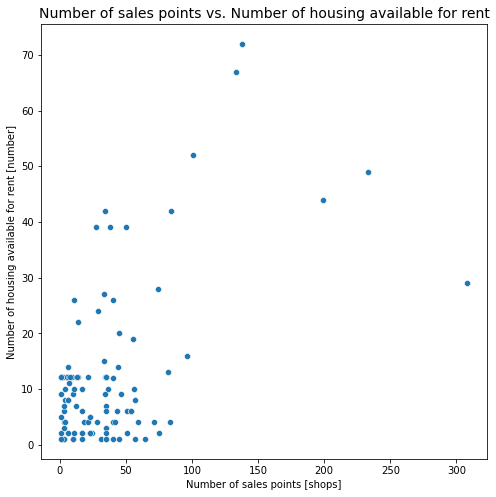

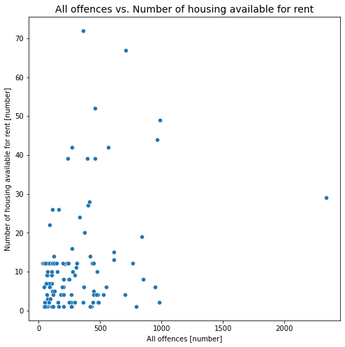

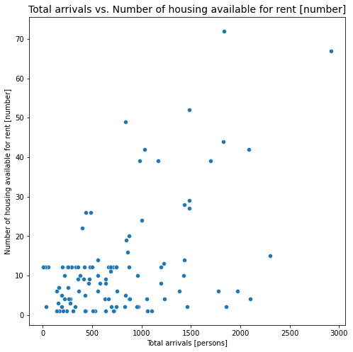

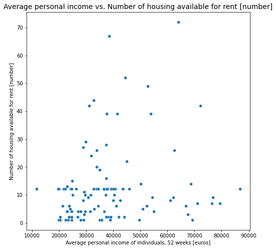

```python
f, ax = plt.subplots(1,1, figsize=(8, 8))
sns.scatterplot(x="Number of sales points [shops]", y="Number of housing available for rent [number]", data=Hagdata_2018, ax=ax);
ax.set_title('Number of sales points vs. Number of housing available for rent', fontsize=14)
plt.show();

f, ax = plt.subplots(1,1, figsize=(8, 8))
sns.scatterplot(x="All offences [number]", y="Number of housing available for rent [number]",data=Hagdata_2018, ax=ax);
ax.set_title('All offences vs. Number of housing available for rent', fontsize=14)
plt.show();

f, ax = plt.subplots(1,1, figsize=(8, 8))
sns.scatterplot(x="Total arrivals [persons]", y="Number of housing available for rent [number]", data=Hagdata_2018, ax=ax);
ax.set_title('Total arrivals vs. Number of housing available for rent [number]', fontsize=14)
plt.show();

f, ax = plt.subplots(1,1, figsize=(8, 8))
sns.scatterplot(x="Average personal income of individuals, 52 weeks [euros]", y="Number of housing available for rent [number]", data=Hagdata_2018, ax=ax);
ax.set_title('Average personal income vs. Number of housing available for rent [number]', fontsize=14)
plt.show();
```

```python
corr_matrix = Hagdata_2018.corr()
corr_matrix['Number of housing available for rent [number]'].sort_values(ascending=False)
```

```
Number of housing available for rent [number]                     1.000000
Number of sales points [shops]                                    0.549906
Total arrivals [persons]                                          0.488962
Number of employed persons [persons]                              0.354643
All offences [number]                                             0.298179
Number of residents per 1-1 [persons]                             0.244865
Average personal income of individuals, 52 weeks [euros]          0.206862
average home occupation (BAG) [residents/residential property]   -0.155781
Name: Number of housing available for rent [number], dtype: float64
```

Based on the correlation coefficient, we initially assume the following linear relationship：

#### The regression model would be : y = β1 *x1 + β2* x2 + β3 *x3 + β4* x4 + β5 *x5 + β6* x6 + β7* x7 +α

y - Number of housing available for rent  
x1 - Number of residents  
x2 - Number of employed persons  
x3 - average home occupation (BAG)  
x4 - Number of sales points  
x5 - Total arrivals  
x6 - All offences  
x7 - Average personal income of individuals  
β1 - coefficient of x1  
β2 - coefficient of x2  
β3 - coefficient of x3 ...  
α - intercept

```python
Hagdata_2018_corr = Hagdata_2018[["Number of employed persons [persons]","Number of residents per 1-1 [persons]","average home occupation (BAG) [residents/residential property]",'Number of housing available for rent [number]','Number of sales points [shops]','Total arrivals [persons]','All offences [number]','Average personal income of individuals, 52 weeks [euros]']]
```

```python
print(Hagdata_2018_corr.corr())
```

```
                                                    Number of employed persons [persons]  \
Number of employed persons [persons]                                            1.000000
Number of residents per 1-1 [persons]                                           0.029931
average home occupation (BAG) [residents/reside...                             -0.099533
Number of housing available for rent [number]                                   0.354643
Number of sales points [shops]                                                  0.425637
Total arrivals [persons]                                                        0.281953
All offences [number]                                                           0.476483
Average personal income of individuals, 52 week...                              0.063415

                                                    Number of residents per 1-1 [persons]  \
Number of employed persons [persons]                                             0.029931
Number of residents per 1-1 [persons]                                            1.000000
average home occupation (BAG) [residents/reside...                              -0.041810
Number of housing available for rent [number]                                    0.244865
Number of sales points [shops]                                                   0.317113
Total arrivals [persons]                                                         0.802916
All offences [number]                                                            0.543034
Average personal income of individuals, 52 week...                              -0.384633

                                                    average home occupation (BAG) [residents/residential property]  \
Number of employed persons [persons]                                                        -0.099533
Number of residents per 1-1 [persons]                                                       -0.041810
average home occupation (BAG) [residents/reside...                                           1.000000
Number of housing available for rent [number]                                               -0.155781
Number of sales points [shops]                                                              -0.129113
Total arrivals [persons]                                                                    -0.023739
All offences [number]                                                                       -0.112542
Average personal income of individuals, 52 week...                                          -0.219216

                                                    Number of housing available for rent [number]  \
Number of employed persons [persons]                                                     0.354643
Number of residents per 1-1 [persons]                                                    0.244865
average home occupation (BAG) [residents/reside...                                      -0.155781
Number of housing available for rent [number]                                            1.000000
Number of sales points [shops]                                                           0.549906
Total arrivals [persons]                                                                 0.488962
All offences [number]                                                                    0.298179
Average personal income of individuals, 52 week...                                       0.206862

```

[output cut: 24 more lines]

```
Number of housing available for rent [number]                    0.298179
Number of sales points [shops]                                   0.768230
Total arrivals [persons]                                         0.645300
All offences [number]                                            1.000000
Average personal income of individuals, 52 week...              -0.336982

                                                    Average personal income of individuals, 52 weeks [euros]
Number of employed persons [persons]                                                         0.063415
Number of residents per 1-1 [persons]                                                       -0.384633
average home occupation (BAG) [residents/reside...                                          -0.219216
Number of housing available for rent [number]                                                0.206862
Number of sales points [shops]                                                              -0.029889
Total arrivals [persons]                                                                    -0.287109
All offences [number]                                                                       -0.336982
Average personal income of individuals, 52 week...                                           1.000000
```

From the correlation we can see that for the variables : Number of residents and Total arrivals, the correlation is 0.802916 > 0.8, so we should delete one to make sure the model is not influenced by the multicollinearity.

```python
del Hagdata_2018['Number of residents per 1-1 [persons]']
```

```python
X = Hagdata_2018[["Number of sales points [shops]","Number of employed persons [persons]","average home occupation (BAG) [residents/residential property]","All offences [number]","Average personal income of individuals, 52 weeks [euros]","Total arrivals [persons]"]]
```

```python
vif = [variance_inflation_factor(X.values, X.columns.get_loc(i)) for i in X.columns]
vif
```

```
[4.282291919355732,
 2.2909623173196985,
 4.060716444081633,
 7.449687991735165,
 3.8570030267811894,
 4.592530479600121]
```

Now we can run the regression model:

When VIF<10, we consider that there is no multicollinearity.

```python
y = Hagdata_2018['Number of housing available for rent [number]']
y_train = y
```

```python
from sklearn.model_selection import train_test_split
X_train,X_test,y_train,y_test=train_test_split(X,y,test_size = 0.2,random_state=42)
```

```python
LR = LinearRegression()
```

```python
LR.fit(X_train,y_train)
```

```
LinearRegression()
```

```python
X = sm.add_constant(X)
```

```python
est = sm.OLS(y,X)
```

```python
est = est.fit()
```

```python
est.summary()
```

OLS Regression Results

| Dep. Variable: | Number of housing available for rent [number] | R-squared: | 0.560 |
| --- | --- | --- | --- |
| Model: | OLS | Adj. R-squared: | 0.535 |
| Method: | Least Squares | F-statistic: | 22.68 |
| Date: | Fri, 15 Oct 2021 | Prob (F-statistic): | 4.18e-17 |
| Time: | 18:28:14 | Log-Likelihood: | -410.50 |
| No. Observations: | 114 | AIC: | 835.0 |
| Df Residuals: | 107 | BIC: | 854.2 |
| Df Model: | 6 |  |  |
| Covariance Type: | nonrobust |  |  |

|  | coef | std err | t | P>\|t\| | [0.025 | 0.975] |
| --- | --- | --- | --- | --- | --- | --- |
| const | -0.6090 | 4.462 | -0.136 | 0.892 | -9.455 | 8.237 |
| Number of sales points [shops] | 0.2000 | 0.032 | 6.164 | 0.000 | 0.136 | 0.264 |
| Number of employed persons [persons] | 0.0008 | 0.000 | 2.568 | 0.012 | 0.000 | 0.001 |
| average home occupation (BAG) [residents/residential property] | -1.1097 | 0.998 | -1.112 | 0.269 | -3.088 | 0.869 |
| All offences [number] | -0.0275 | 0.006 | -4.619 | 0.000 | -0.039 | -0.016 |
| Average personal income of individuals, 52 weeks [euros] | 0.0001 | 7.01e-05 | 1.840 | 0.068 | -9.95e-06 | 0.000 |
| Total arrivals [persons] | 0.0130 | 0.002 | 6.430 | 0.000 | 0.009 | 0.017 |

| Omnibus: | 6.723 | Durbin-Watson: | 1.976 |
| --- | --- | --- | --- |
| Prob(Omnibus): | 0.035 | Jarque-Bera (JB): | 6.656 |
| Skew: | 0.591 | Prob(JB): | 0.0359 |
| Kurtosis: | 3.051 | Cond. No. | 2.15e+05 |

Notes:  
[1] Standard Errors assume that the covariance matrix of the errors is correctly specified.  
[2] The condition number is large, 2.15e+05. This might indicate that there are  
strong multicollinearity or other numerical problems.

#### Based on the output:

- Adj. R-squared = 0.535  
  Significant improvement compared to the previous model (without additional variables - Adj. R-squared = 0.171).
- P value  
  The p value of the intercept term is 0.892, and at the significance level of 5%, we can not reject the original hypothesis, i.e. which means that we can believe that the alpha estimate is not significantly different from 0.

The p value of the coefficient of average home occupation (BAG) [residents/residential property] is 0.269,at the significance level of 5%, we can not reject the original hypothesis, i.e. which means that we can believe that the alpha estimate is not significantly different from 0.

```python
r2 = LR.score(X_test, y_test)
```

```python
print(LR.score(X_train, y_train))
```

```
0.5416856551519469
```

```python
print(f'R^2 = {r2:.5}')
```

```
R^2 = 0.57783
```

### 6.Model adjustment

```python
Hagdata_2018['average home occupation (BAG) [residents/residential property]'] = np.log2(Hagdata_2018['average home occupation (BAG) [residents/residential property]'])
```

```python
Hagdata_2018.rename(columns = {'average home occupation (BAG) [residents/residential property]': 'LN(average home occupation)'},
           inplace = True)
```

```python
Hagdata_2018.head()
```

|  | neighb_cbs | neigb_cijf | geometry | LN(average home occupation) | Number of employed persons [persons] | Number of housing available for rent [number] | Number of sales points [shops] | All offences [number] | Total arrivals [persons] | Average personal income of individuals, 52 weeks [euros] |
| --- | --- | --- | --- | --- | --- | --- | --- | --- | --- | --- |
| 0 | Oostduinen | 70 Oostduinen | POLYGON ((4.30290 52.12832, 4.30298 52.12827, ... | 1.132295 | 2495.20952 | 12.123596 | 35.164105 | 308.810811 | 743.772727 | 37819.158608 |
| 1 | Belgisch Park | 71 Belgisch Park | POLYGON ((4.28056 52.11706, 4.28053 52.11706, ... | 0.992768 | 4062.00000 | 52.000000 | 101.000000 | 460.000000 | 1487.000000 | 44400.000000 |
| 2 | Westbroekpark | 73 Westbroekpark | POLYGON ((4.29171 52.10745, 4.29181 52.10739, ... | 0.790772 | 367.00000 | 7.000000 | 34.921569 | 106.000000 | 164.000000 | 71000.000000 |
| 3 | Duttendel | 74 Duttendel | POLYGON ((4.32252 52.10768, 4.32252 52.10766, ... | 0.807355 | 2664.00000 | 3.000000 | 34.921569 | 74.000000 | 156.000000 | 67600.000000 |
| 4 | Nassaubuurt | 48 Nassaubuurt | POLYGON ((4.31943 52.09247, 4.31943 52.09247, ... | 1.124328 | 4934.00000 | 7.000000 | 12.000000 | 82.000000 | 255.000000 | 76400.000000 |

```python
from sklearn.model_selection import train_test_split
X_train,X_test,y_train,y_test=train_test_split(X,y,test_size = 0.2,random_state=42)
```

```python
X = Hagdata_2018[["Number of sales points [shops]","LN(average home occupation)","All offences [number]","Total arrivals [persons]"]]
```

```python
X = sm.add_constant(X)
```

```python
est = sm.OLS(y,X)
```

```python
est = est.fit()
```

```python
est.summary()
```

OLS Regression Results

| Dep. Variable: | Number of housing available for rent [number] | R-squared: | 0.517 |
| --- | --- | --- | --- |
| Model: | OLS | Adj. R-squared: | 0.500 |
| Method: | Least Squares | F-statistic: | 29.21 |
| Date: | Fri, 15 Oct 2021 | Prob (F-statistic): | 1.68e-16 |
| Time: | 18:28:14 | Log-Likelihood: | -415.76 |
| No. Observations: | 114 | AIC: | 841.5 |
| Df Residuals: | 109 | BIC: | 855.2 |
| Df Model: | 4 |  |  |
| Covariance Type: | nonrobust |  |  |

|  | coef | std err | t | P>\|t\| | [0.025 | 0.975] |
| --- | --- | --- | --- | --- | --- | --- |
| const | 8.7937 | 2.693 | 3.266 | 0.001 | 3.457 | 14.130 |
| Number of sales points [shops] | 0.2262 | 0.031 | 7.224 | 0.000 | 0.164 | 0.288 |
| LN(average home occupation) | -4.9673 | 2.109 | -2.355 | 0.020 | -9.148 | -0.787 |
| All offences [number] | -0.0287 | 0.005 | -5.441 | 0.000 | -0.039 | -0.018 |
| Total arrivals [persons] | 0.0127 | 0.002 | 6.096 | 0.000 | 0.009 | 0.017 |

| Omnibus: | 6.188 | Durbin-Watson: | 1.878 |
| --- | --- | --- | --- |
| Prob(Omnibus): | 0.045 | Jarque-Bera (JB): | 6.007 |
| Skew: | 0.561 | Prob(JB): | 0.0496 |
| Kurtosis: | 3.078 | Cond. No. | 3.71e+03 |

Notes:  
[1] Standard Errors assume that the covariance matrix of the errors is correctly specified.  
[2] The condition number is large, 3.71e+03. This might indicate that there are  
strong multicollinearity or other numerical problems.

#### Based on the output:

- Adj. R-squared = 0.500  
  Compared to the previous model, it slightly decreased.
- P value  
  The p value of the intercept term drops from 0.892 to 0.001, and at the significance level of 5%, we can reject the null hypothesis, i.e. which means that we can believe that the alpha estimate is significantly different from 0.  
  The p value of the coefficient of all the variables are < 0.05, we can reject the null hypothesis at the same significance level of 5%. This means we can believe that these variables have linear relationship with the number of houses available for renting.

The regression model will be :

##### y = 0.2262 *x1 - 4.9673* x2 - 0.0287 *x3 + 0.0127* x4 + 8.7937

y - Number of housing available for rent  
x1 - Number of sales points  
x2 - LN(average home occupation)  
x3 - All offences  
x4 - Total arrivals

##### y = 0.2262 *Number of sales points - 4.9673* LN(average home occupation) - 0.0287 *All offences + 0.0127* Total arrivals + 8.7937

This result can be explained：

First, people are more inclined to rent houses in areas with convenient living, so there is a higher demand for houses with supermarkets nearby, even if they are also slightly more expensive, which will stimulate supply in a short period of time, and homeowners will be more confident about the performance of houses with better surrounding facilities in the rental market as well.

Total arrivals can be considered as an explanation for migrant workers, the more people find work in The Hague, the stronger the demand for rental housing, and likewise, the increased demand will stimulate the market price, and households will be more inclined to rent their homes.

A plausible explanation for the crime rate is that houses in neighborhoods with higher crime rates are inherently harder to sell in the buying and selling market, while people do not prioritize housing in neighborhoods with higher crime rates, and thus the number of houses available for rent in neighborhoods with higher crime rates decreases. The relationship between LN(average home occupancy) and rentable homes is roughly the same as our hypothesis, where a higher average home occupancy means that the more residents living in a property, the fewer opportunities there are for renting.

### 7.Prediction and discussion

```python
from sklearn.linear_model import LinearRegression

LR = LinearRegression()
LR.fit(X_train,y_train)
y_pred=LR.predict(X_test)
```

```python
y_pred
```

```
array([-3.27036118, 12.72457473, 15.67606781,  7.41721444, 22.57279482,
       25.15778744, 13.21326679,  7.10707851, 17.05344419,  7.66791331,
        2.67589301,  5.60457977,  2.64682248,  7.47562143, 48.65672098,
       11.88303373, 23.65964645,  5.16311762,  2.89206698, 17.17539349,
        3.85970014, 15.18547258, 10.44578824])
```

```python
r2 = LR.score(X_test, y_test)
print(f'R^2 = {r2:.5}')
```

```
R^2 = 0.57783
```

```python
from sklearn.metrics import mean_squared_error
```

```python
print(mean_squared_error(y_pred, y_test))
print(mean_squared_error(y_train, LR.predict(X_train)))
```

```
103.07497148978518
73.93489947478038
```

```python
X.shape
```

```
(114, 5)
```

```python
y.shape
```

```
(114,)
```

```python
from matplotlib import rcParams
```

```python
fig = plt.figure(figsize = (10,6))
```

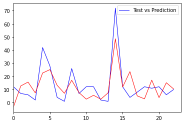

```python
plt.plot(range(y_test.shape[0]),y_test,color = "blue",
        linewidth = 1.0, linestyle = '-')

plt.plot(range(y_test.shape[0]),y_pred,color = "red",
        linewidth = 1.0, linestyle = '-')
plt.xlim((0,23))
plt.legend(['Test vs Prediction'])
```

#### Discussion

In addition to this, demographic characteristics may also have a linear relationship with the dependent variable, where the more single people there are, then there will be more rentable space for a property relative to a large family. Overall, a large part of the reason the model is not sufficiently accurate is that the independent variables that significantly affect the dependent variable are not included. So the model can be improved by adding more explanatory variables and then performing regression analysis in the future. And if the model is sufficiently well developed (rather than a simple linear regression), this type of analysis can provide real estate agents with a rough estimate of pricing levels by forecasting the market for available rental housing.